# Machine Learning Phase 2 Report 2023 sem1

### s3910501

23.08.02

### Part 1: Defining Phase 1 Outcomes and Phase 2 Scope

#### Part 1.1: Phase 1 Summary

##### Part 1.1.1: Dataset Information and Source

##### Part 1.1.2: Data Cleaning and Processing

##### Part 1.1.3: Data Exploration and Visualization

#### Part 1.2: Defining Scope

##### Part 1.2.1: Discovering Output

##### Part 1.2.2: Discussion of Project Limitations

##### Part 1.2.3: Determination of Findings

#### Part 1.3: Overview of Methodology

##### Part 1.3.1: Data Preparation for Predictive Modelling

##### Part 1.3.2: Discovery

### Part 2: Discovery

#### Part 2.1: Feature Selection

##### Part 2.1.1: Feature Selection by Correlation for Linear Regression

##### Part 2.1.2: Feature Selection by Mutual Information for Linear Regression

##### Part 2.1.3: Reviewing Linear Regression MAE Scores

##### Part 2.1.4: Reviewing Linear Regression RSQ Scores By Features

##### Part 2.1.5: Reviewing All Models and FS Methods by RSQ

#### Part 2.2: Fine-tuning and Performance Analysis

##### Part 2.2.1: Random Forest Cross-Validation: Grid Search

##### Part 2.2.2: Random Forest Cross-Validation: Random Search

##### Part 2.2.3: Gradient Boosting Cross-Validation: Grid Search

##### Part 2.2.4: Gradient Boosting Cross-Validation: Random Search

##### Part 2.2.5: Summary of Cross-Validation Results

##### Part 2.2.6: Visualising Relative Feature Importance: Gradient Boosting

##### Part 2.2.7: Visualising Relative Feature Importance: Random Forest

#### Part 2.3: Model Comparison

##### Part 2.3.1: Compare Random Forest CV Feature Importance

##### Part 2.3.2: Compare Gradient Boosting CV Feature Importance

##### Part 2.3.3: Comparing the Predictions of the Random Forest Model

##### Part 2.3.4: Comparing the Predictions of the Gradient Boosting Model

##### Part 2.3.5: Commentary Regarding Paired T-test Results

### Part 3: Discussion of Limitations and Critiques

#### Part 3.1: Data Limitations

#### Part 3.2: Model Limitations

### Part 4: Discussion

##### Task 4.1: Project Summary

##### Task 4.2: Project Findings

##### Part 4.3: Conclusions

### Appendices

#### Appendix A: Phase 1 Visuals

#### Appendix B: Summary Statistics on Raw Data

#### Appendix C: Models that returned negative R-Square

#### Appendix D: Comprehensive Regression Scoring

## Part 1: Defining Phase 1 Outcomes and Phase 2 Scope

### Part 1.1: Phase 1 Summary

#### Part 1.1.1: Dataset Information and Source

This project's purpose is to predict the Total ESG Score (our target feature, esgR) for constiuents to the Standard&Poor 500 Index (the index) based on metrics utilised by Industry participants in defining Investment Performance and Company Performance, in combination with categorical information regarding the constituents Global Industry Classification Standard (GICS) categorisation.

The Phase One (p1) report of this project provided:

- A high-level explanation of the data's content and source,
- Instructions on preprocessing and cleaning the data,
- Summary information regarding categorical and quantitative variables,
- A Multi-faceted visual exploration of the inter-play between different variables.

The contents of the data were defined by global rating agency Standard & Poor (SP) as the S&P500 index (the index) which observed 501 index constituents as at January 2023. These observations represented 11 of 11 Sectors and 118 of 163 Industries. *(spglobal, 2023)*.

These observations were uniquely identified by their stock symbols (symbols, primary key) and formed the spine of what would be become this reports working dataframe whose breadth covers each observations;

- Operational Domicile (GICS sector & industry)
- Non-Financial Risk Metrics (ESG and Controversy Ratings),
- Financial Risk Metrics (Invesment Performance and Accounting Metrics).

#### Part 1.1.2: Data Cleaning and Processing

Data wrangling and pre-processing outlined 421 complete cases of a total 501 possible for further inference through the following process;

Data Cleaning;

6. Separated rows with missing values in any of the variables to a separate frame for gap analysis,
7. Preserved the unique keys by moving them out of the df itself and instead to rownames,
8. Reviewed summary statistics for Quantitative and Qualitative information,
9. Defined the target feature as Total ESG Rating and research objectives.

#### Part 1.1.3: Data Exploration and Visualisation

Across these observations, exploratory data analysis indicated a breadth and width to the numeric and categorical variables in the frame, whose values were then graphically illustrated presenting;

1. A single-variable chart illustrating the sector-level breakdown by relative frequency for which sectors were more and less represented within the data.(Fig 1, App. A1),
2. A single-variable chart illustrating the sector-level breakdown by relative frequency denoting how campy observations each sector was missing across the data (Fig 2, App. A2),
3. A two-variable boxplot indicating the spread and distribution of Total ESG Scores by sector (Fig 3, App. A3),
4. A two-variable boxplot indicating the spread and distribution of Market Capitalisation by sector (Fig 4, App. A4),
5. A three-variable scatter plot indicating the market capitalisation per sector faceted by controversy level(Fig 5, App. A5), and
6. A three-variable inverted boxplot which demonstrated how relative Beta risk was when faceted by controversy scores (Fig 6, App. A6).

These charts have been indexed as noted above as appendices.

### Part 1.2: Phase Two Report Overview

The segmentation of this report's process and findings sits across the following sections; defining scope, discovering output, discussing limitations, and determination of findings.

#### Part 1.2.1: Defining Scope

Continuing on from Phase 1, this report for Phase 2 (p2) considers the construction and analysis of a regression model employed to predict the index constituents esgR score (the target) based on categorical GICS information (Sector, Industry) and financial risk and reward measures contained within the data (the predictors).

#### Part 1.2.2: Discovering output

Initial steps are taken to conclude data preparation by one-hot encoding categorical variables and standardizing numeric variables prior to measurement.

Initailly, Linear Regession models utilising Mutual Informatino and Correlation for feature selection are presented in contrast illustrating the relative differences in importance on a feature for feature basis. All 18 features are included and commentary is offered as to each respective makeup. Both linear models are scored by Mean Aboslute Error and R-Squared for the full sequence of feautres and illustrations are employed to contextualise the relationship between scoring and number of features included.

A comprehensive review is then conducted where Linear, Gradient Boosting, Decision Tree, and Random Forest regression models are scored by MAE and RSQ across both Correlation and Mutual Information methods providing contrasting context to how each iteration sits relatively. All values are then displayed measuring each models individual relationship between RSQ and number of features.

Two different models are identified to the model performance analysis where each is processed through random and grid search cross-validation techniques across 5 folds. The relative scores and features are organised and contrast against the respective model identified in the feature selection stage.

Model performance analysis then employs both grid and random search cross-validation methods on a feature-for-feature basis to review against benchmark models identified through feature selection. Relative performance is contrast and commentary speaks to what differences arise between the CV outputs and the feature selection approach.

Model comparison takes the form of utilising paired t-tests, testing the mean to determine the likelihood of a non-zero difference between the mean values of feature importance, and model predictions. These differences are visualised and final commentary leads into the discussion on limitations to the research.

```python
# TASK 1.3
# IMPORT LIBRARIES
import pandas as pd
import numpy as np
import warnings
warnings.filterwarnings("ignore")

import io
import requests

from sklearn.preprocessing import RobustScaler, LabelEncoder
from sklearn.model_selection import train_test_split

# TO VIEW ALL COL
pd.set_option('display.max_columns', None)

## GET ESG DATA
df_source = "Phase2_Group_21.csv"
df = pd.read_csv(df_source)
# REV FOR MISSING VAL
print(df.isna().sum())
workingData = df
# DATA PREP FOR PRED MODELLING

## DEF TARGET AND SPLIT OUT PREDICTORS
y = df['TotalESGScore']
X = df.drop(['TotalESGScore'], axis=1)

## MOD NOMINAL CATEGORICAL VAR TO NUMERIC W/ ONE HOT ENCODING
X_encoded = pd.get_dummies(X, columns=['Sector'], drop_first=True)
## MOD ORDINGAL CATEGORICAL VAR TO NUMERIC VIA INTEGER ENCODING
controversy_encoder = LabelEncoder()
X_encoded['ControversyLevel'] = controversy_encoder.fit_transform(X['ControversyLevel'])
## MOD NUMERIC FEATURES W/ ROBSUT SCALING FOR OUTLIERS
numeric_features = X_encoded.select_dtypes(include=['float64', 'int64']).columns
scaler = RobustScaler()
X_scaled = scaler.fit_transform(X_encoded)

# REV SAMPLE OF DATA (PRED)
print(X.sample(n=5, random_state=999))
# REV SAMPLE OF DATA (TARG)
print(y.sample(n=5, random_state=999))
# REV SUM STATS FOR ALL
print(df.describe(include='all'))

# X_train, y_train, X_test

# Import the train_test_split function
from sklearn.model_selection import train_test_split

testSize = 0.2

# Split the data into training and testing sets
X_train, X_test, y_train, y_test = train_test_split(X_scaled, y, test_size=testSize, random_state=21)

custom_labels = X_encoded.columns.tolist()
```

```
Sector              0
TotalESGScore       0
ControversyLevel    0
MarketCap           0
Beta                0
EPS                 0
StDev_1y            0
StDev_3y            0
LnRet_1y            0
LnRet_3y            0
dtype: int64
                     Sector  ControversyLevel     MarketCap      Beta    EPS  \
292  Communication Services                 1  1.861475e+10  0.847642   6.65
345        Consumer Staples                 2  1.619694e+10  0.214989   6.64
221  Information Technology                 0  5.812299e+10  1.369106  24.57
288  Consumer Discretionary                 2  3.598529e+09  0.917311  -0.30
219        Consumer Staples                 3  4.794826e+10  0.687895   1.96

     StDev_1y  StDev_3y  LnRet_1y  LnRet_3y
292  0.020622  0.023096  0.139316  0.125902
345  0.014966  0.016591  0.186336  0.509231
221  0.030714  0.031744 -0.111697  0.791958
288  0.026227  0.027926 -0.451239 -0.242301
219  0.016112  0.019747  0.173710  0.372898
292    18.2
345    31.0
221    16.9
288    14.3
219    35.3
Name: TotalESGScore, dtype: float64
                        Sector  TotalESGScore  ControversyLevel     MarketCap  \
count                      421     421.000000        421.000000  4.210000e+02
unique                      11            NaN               NaN           NaN
top     Information Technology            NaN               NaN           NaN
freq                        60            NaN               NaN           NaN
mean                       NaN      21.556295          1.862233  8.065944e+10
std                        NaN       7.041428          0.966103  2.165687e+11
min                        NaN       7.000000          0.000000  8.810063e+06
25%                        NaN      16.000000          1.000000  1.684141e+10
50%                        NaN      21.300000          2.000000  3.238837e+10
75%                        NaN      26.500000          2.000000  6.585069e+10
max                        NaN      46.200000          5.000000  2.760000e+12

              Beta         EPS    StDev_1y    StDev_3y    LnRet_1y    LnRet_3y
count   421.000000  421.000000  421.000000  421.000000  421.000000  421.000000
unique         NaN         NaN         NaN         NaN         NaN         NaN
top            NaN         NaN         NaN         NaN         NaN         NaN
freq           NaN         NaN         NaN         NaN         NaN         NaN
mean      1.031866    8.160356    0.021813    0.024937   -0.130985    0.203000
std       0.402578   25.538403    0.006314    0.006707    0.294199    0.387541
min       0.163265  -35.220000    0.010927    0.013196   -1.063473   -1.829969
25%       0.752638    2.300000    0.017166    0.020459   -0.308682    0.003343
50%       1.031667    4.760000    0.020696    0.023280   -0.118103    0.224591
75%       1.280436    8.460000    0.025020    0.028345    0.054601    0.416212
max       2.489795  480.420000    0.049294    0.059376    0.663748    1.485426
```

```python
# # GET CSV FOR REPLICATION

# csvFile = "Phase2_Group21.csv"

# pd.DataFrame(df).to_csv(csvFile, index=False)
```

```python
custom_labels
```

```
['ControversyLevel',
 'MarketCap',
 'Beta',
 'EPS',
 'StDev_1y',
 'StDev_3y',
 'LnRet_1y',
 'LnRet_3y',
 'Sector_Consumer Discretionary',
 'Sector_Consumer Staples',
 'Sector_Energy',
 'Sector_Financials',
 'Sector_Health Care',
 'Sector_Industrials',
 'Sector_Information Technology',
 'Sector_Materials',
 'Sector_Real Estate',
 'Sector_Utilities']
```

### Part 1.3: Overview of Methodology

The underlying methodology of this phase is that of tuning and training a regression model to predict the total ESG Ratings for SP500 companies in the index as at January 2023.

The methodolody is broken into Data Preparation, and Discovery phases as below;

#### Part 1.3.1: Data preparation for preditctive modelling

Now with everything pointing the right way, data was split for training:testing (4:1) and a random state (21, this group number) was assigned for reproducability. Data was not sampled due to existing sample size being relatively small to begin with.

#### Part 1.3.2: Discovering Best Fit (Part 2)

Feature Selection (FS) is initially performed on a linear (LN) regression model utilising two methods; correlation (CR) and mutual information (MI). All predictor variables are reviewed for their value to the overall model.

Observations are made as to how the best features vary between FS methods for the LN model with light discussion on their relevance to the overall project purpose.

MAE scores for both FS methods are graphically represented demonstrating the complexity of the relationship as features selected increase.

A more comprehensive search for model fitting and tuning is then undertaken where Random Forest (RF), Gradient Boosting (GB), and Decision Tree (DT) regression models are contrast against the initial Linear approach using both Mutual Information and Correlation feature selection methods over the full range of features (1:18).

By starting with the LN model, the strategy is to derive a benchmark for contrasting the more sophisticated methods (RF,DT,GB). All models are then scored by Mean Absolute Error (MAE) and R-squared (RSQ) in order to determine a best-in-class fit.

One model scoring best over both measures is identified and carried forward for a Cross-Validation (CV) with a second model scoring a similar RSQ with less features into a model performance comparison where both regression models are used to benchmark the grid search (GS) and random search (RS) CV scores across the full suite of features measuring both RSQ and MAE.

Succinct performance commentary is provided relative to each best-in-class model as well as well as on a feature-for-feature basis.

Paired t-tests are then conducted to compare similarities between feature importance in cross-validation results as well as the predictions agaisnt each model relative to each cross-validation method.

## Part 2: Discovery

The underlying task is to seek to understand how well one may predict non-financial risk based on financial risk features. The inclusion of categorical variables is intended to facet financial risk measures working from an assumption that constituent specific performance may vary by GICS sector.

This is confirmed in Appendix B where the data are grouped by sector and numeric variables have summay statistics run through ANOVA.

The strategy here-in is to move from simple through to more sophisticated models reviewing all options in order to consider the context for a best-in-class model.

```python
# # Task 2.1 Fig 1a,b: FS: by CR AND MI
import numpy as np
from matplotlib import pyplot
from sklearn.datasets import make_regression
from sklearn.model_selection import train_test_split
from sklearn.feature_selection import SelectKBest,f_regression,mutual_info_regression
from sklearn.linear_model import LinearRegression
from sklearn.metrics import mean_absolute_error, r2_score

# DEF FUN FS
def select_feat_Correl(X_train, y_train, X_test):
	# GET subset of features
	fsCorrel = SelectKBest(score_func=f_regression, k=kTEST)
	# GET relationship from training
	fsCorrel.fit(X_train, y_train)
	# ORG transform train input data
	X_train_fsCorrel = fsCorrel.transform(X_train)
	# ORG transform test input data
	X_test_fsCorrel = fsCorrel.transform(X_test)
	# RET values
	return X_train_fsCorrel, X_test_fsCorrel, fsCorrel

kTEST=18

# FS FOR LN+CR
X_train_fsCorrel, X_test_fsCorrel, fsCorrel = select_feat_Correl(X_train, y_train, X_test)
# FIT model
model = LinearRegression()
model.fit(X_train_fsCorrel, y_train)
# REV model
yhatCorrel = model.predict(X_test_fsCorrel)
# REV predictions
maeCorrel = mean_absolute_error(y_test, yhatCorrel)
rsqCorrel = r2_score(y_test, yhatCorrel)

# DEF indices of top kTEST features based on MI scores
top_feat_indCorrel = np.argsort(fsCorrel.scores_)[::-1][:kTEST]
# GET names of top kTEST features
top_feat_namesCorrel = [custom_labels[i] for i in top_feat_indCorrel]

#################################################
# Fig 1b: Top Features by Mutual Information Score
# DEF FS FUN

def select_features_mutInfo(X_train, y_train, X_test):
	# DEF feature selection
	fsMutInfo= SelectKBest(score_func=mutual_info_regression, k=kTEST)
	# learn relationship from training data
	fsMutInfo.fit(X_train, y_train)
	# transform train input data
	X_train_fsMutInfo = fsMutInfo.transform(X_train)
	# transform test input data
	X_test_fsMutInfo = fsMutInfo.transform(X_test)
	return X_train_fsMutInfo, X_test_fsMutInfo, fsMutInfo

# kTEST=kTEST

# FS for MI
X_train_fsMutInfo, X_test_fsMutInfo, fsMutInfo = select_features_mutInfo(X_train, y_train, X_test)
# FIT model
model = LinearRegression()
model.fit(X_train_fsMutInfo, y_train)
# REV model
yhatMutInfo = model.predict(X_test_fsMutInfo)
# REV predictions
maeMutInfo = mean_absolute_error(y_test, yhatMutInfo)

rsqMutInfo = r2_score(y_test, yhatMutInfo)
# GET indices of top feat by MI scores
top_feat_indMutInfo = np.argsort(fsMutInfo.scores_)[::-1][:kTEST]

# GET names of the top feat
top_feat_namesMutInfo = [custom_labels[i] for i in top_feat_indMutInfo]
```

### Part 2.1: Feature Selection

Starting at simple, the first approach to modeling the available features in the data involves reviewing a linear (LN) regression model utilising two methods of Feature Selection (FS); correlation (CR) and mutual information (MI). These FS methods have been chosen due to the target variable being continuous.

This first approach (LN w/CR & MI) will serve as a benchmark by regressing against all features (18) affording insight to how important each feature is.

#### Part 2.1.1: Feature Selection by Correlation for Linear Regression

Figure 1a visualises exponentially decreasing correlation from left to right, with the higher and more important features sitting to the left.

Four features sit over 30% with the three highest being categorical (Controversy, Energy Sector and Real Estate Sector), and the fourth being log returns over 1 year. After this there is a steep shift that see's market capitalisation and Earnings Per Share (EPS), two financial metrics, scoring lowest overall.

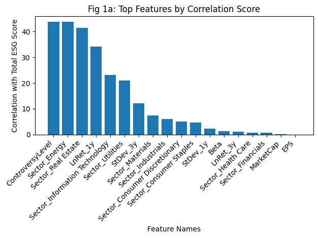

```python
# Fig 1a: Top Features by Correlation Score
pyplot.bar(range(len(top_feat_indCorrel)), [fsCorrel.scores_[i] for i in top_feat_indCorrel])
pyplot.xticks(range(len(top_feat_indCorrel)), top_feat_namesCorrel, rotation=45, ha="right")
pyplot.xlabel("Feature Names")
pyplot.ylabel("Correlation with Total ESG Score")
pyplot.title("Fig 1a: Top Features by Correlation Score")
pyplot.tight_layout()
pyplot.show()
```

```python
# Part 2.1.1: MAE, RSQ, Ranked Features for LN+CR

print('LN CR MAE: %.3f' % maeCorrel)
print('LN CR RSQ: %.3f' % rsqCorrel)

print(str("LN CR Top Features:"))
for i, feature_name in enumerate(top_feat_namesCorrel):
    print(f"{i + 1}. {feature_name}")
```

```
LN CR MAE: 4.300
LN CR RSQ: 0.409
LN CR Top Features:
1. ControversyLevel
2. Sector_Energy
3. Sector_Real Estate
4. LnRet_1y
5. Sector_Information Technology
6. Sector_Utilities
7. StDev_3y
8. Sector_Materials
9. Sector_Industrials
10. Sector_Consumer Discretionary
11. Sector_Consumer Staples
12. StDev_1y
13. Beta
14. LnRet_3y
15. Sector_Health Care
16. Sector_Financials
17. MarketCap
18. EPS
```

#### Part 2.1.2: Feature Selection by Mutual Information for Linear Regression

Figure 1b identifies 3 year Log Returns being a standout leader, with Log Returns for 1 year and 3 year standard deviation making up three of the top four features. The second highest scoring feature is again the real estate sector. Market Capitalisation is again a virtual no-show this time being joined by 1 year standard deviation on close prices and the health care sector as a categorical variable.

In contrast, Controversy Level is a much relative importance in Fig 1b, and there is a more linear descent across the importance of features using mutual information, relative to the asymptotic decay using correlation. Both of these methods involve placing zero thought into choosing what will and will-not go into the model.

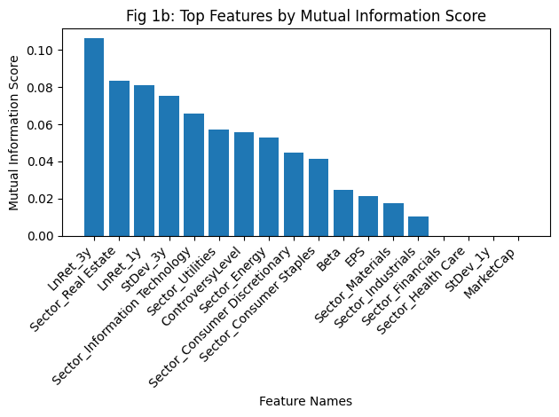

```python
# Fig 1b: Top Features by Mutual Information Score
pyplot.bar(range(len(top_feat_indMutInfo)), [fsMutInfo.scores_[i] for i in top_feat_indMutInfo])
pyplot.xticks(range(len(top_feat_indMutInfo)), top_feat_namesMutInfo, rotation=45, ha="right")
pyplot.xlabel("Feature Names")
pyplot.ylabel("Mutual Information Score")
pyplot.title("Fig 1b: Top Features by Mutual Information Score")
pyplot.tight_layout()
pyplot.show()
```

```python
# APP B?: MAE, RSQ, Ranked Features for LN+MI

print('LN MI MAE: %.3f' % maeMutInfo)
print('LN MI RSQ: %.3f' % rsqMutInfo)

print("LN MI Top Features:")
for i, feature_name in enumerate(top_feat_namesMutInfo):
    print(f"{i + 1}. {feature_name}")
```

```
LN MI MAE: 4.300
LN MI RSQ: 0.409
LN MI Top Features:
1. LnRet_3y
2. Sector_Real Estate
3. LnRet_1y
4. StDev_3y
5. Sector_Information Technology
6. Sector_Utilities
7. ControversyLevel
8. Sector_Energy
9. Sector_Consumer Discretionary
10. Sector_Consumer Staples
11. Beta
12. EPS
13. Sector_Materials
14. Sector_Industrials
15. Sector_Financials
16. Sector_Health Care
17. StDev_1y
18. MarketCap
```

#### Part 2.1.3: Reviewing Linear Regression MAE Scores

Figure 2a illustrates a de-identifed progression in MAE scoring which offers context as to the respective trajectories both FS methods track.

It is observed that both do not follow a continued rate of change, with both offering steep descent from features 1 through 5, before then respectively increasing MAE scores for a short stretch, before ultimately continuing a descent to the same resting place noted above.

Correlation based FS dips lowest at 10 features, which are identified in Fig 1a being; ControversyLevel, 7 of 11 Sectors (Energy, Real Estate, Information Technology, Utilities, Materials, Industrials, and Consumer Discretionary), and finally 2 financial risk measures (LnRet_1y, StDev_3y). This indicates that the correlation feature selection is largely scoring based on the GICS sector that an index constituent operates within.

```python
# Task 2.1, Fig 2
import pandas as pd
import numpy as np
from sklearn.linear_model import LinearRegression
from sklearn.metrics import mean_absolute_error
from sklearn.datasets import make_regression
from sklearn.model_selection import train_test_split
from sklearn.feature_selection import SelectKBest, f_regression, mutual_info_regression
import seaborn as sns
import matplotlib.pyplot as plt

# DEF FUN EVAL MODEL
def evaluate_model(X_train, y_train, X_test, y_test, method, k):
    # DEF feature selection
    X_train_fs, X_test_fs, fs = method(X_train, y_train, X_test, k)
    # FIT model
    model = LinearRegression()
    model.fit(X_train_fs, y_train)
    # REV model
    yhat = model.predict(X_test_fs)
    mae = mean_absolute_error(y_test, yhat)
    return mae

# DEF FUN FS CR
def select_feat_Correl(X_train, y_train, X_test, k):
    fsCorrel = SelectKBest(score_func=f_regression, k=k)
    fsCorrel.fit(X_train, y_train)
    X_train_fsCorrel = fsCorrel.transform(X_train)
    X_test_fsCorrel = fsCorrel.transform(X_test)
    return X_train_fsCorrel, X_test_fsCorrel, fsCorrel

# DEF FUN FS MI
def select_feat_mutInfo(X_train, y_train, X_test, k):
    # DEF feature selection
    fsMutInfo = SelectKBest(score_func=mutual_info_regression, k=k)
    # GET relationship from training data
    fsMutInfo.fit(X_train, y_train)
    # TFR train input data
    X_train_fsMutInfo = fsMutInfo.transform(X_train)
    # TFR test input data
    X_test_fsMutInfo = fsMutInfo.transform(X_test)
    return X_train_fsMutInfo, X_test_fsMutInfo, fsMutInfo

# DEF df for results
results_df_MAE_by_feature = pd.DataFrame(columns=['Method', 'Features', 'MAE'])

for k in range(1, 19):  # LOOP THRU: 1 to 18
    # EVAL FS CR
    mae_correl = evaluate_model(X_train, y_train, X_test, y_test, select_feat_Correl, k)
    results_df_MAE_by_feature = results_df_MAE_by_feature.append({'Method': 'fsCorrel', 'Features': k, 'MAE': mae_correl}, ignore_index=True)
    # EVAL FS MI
    mae_mutinfo = evaluate_model(X_train, y_train, X_test, y_test, select_feat_mutInfo, k)
    results_df_MAE_by_feature = results_df_MAE_by_feature.append({'Method': 'fsMutInfo', 'Features': k, 'MAE': mae_mutinfo}, ignore_index=True)

# 'Method' and 'Features'
results_df_MAE_by_feature = results_df_MAE_by_feature.sort_values(by=['Method', 'Features'])

# DEF custom palette for the line plot
custom_palette = sns.color_palette("husl", n_colors=2)
```

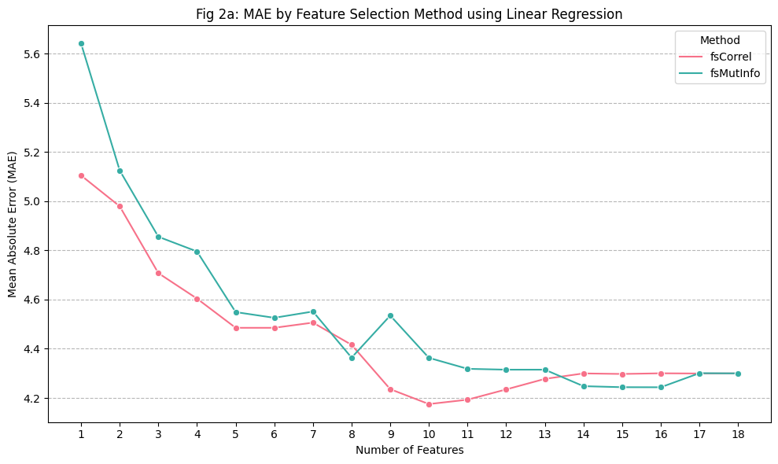

```python
# Fig 2a: MAE by Feature Selection Method using Linear Regression
# DEF PROP OF PLOT
fig, ax1 = pyplot.subplots(figsize=(10, 6))
sns.lineplot(data=results_df_MAE_by_feature, x='Features', y='MAE', hue='Method', palette=custom_palette, marker='o', ax=ax1)
ax1.set_xlabel('Number of Features')
ax1.set_ylabel('Mean Absolute Error (MAE)')
ax1.set_title('Fig 2a: MAE by Feature Selection Method using Linear Regression')
ax1.set_xticks(np.arange(1, 19))
ax1.grid(axis='y', linestyle='--', alpha=0.9)
ax1.legend(title='Method',loc='upper right')
# VIS PLOT
pyplot.tight_layout()
pyplot.show()
```

#### Part 2.1.4: Reviewing Linear Regression RSQ Scores By Features

***Feature Selection by either Correlation or Mutual Information using Linear Regression has a Mean Absolute Error of 4.3 with R-Squared of 40.9% for the full suite of features.***

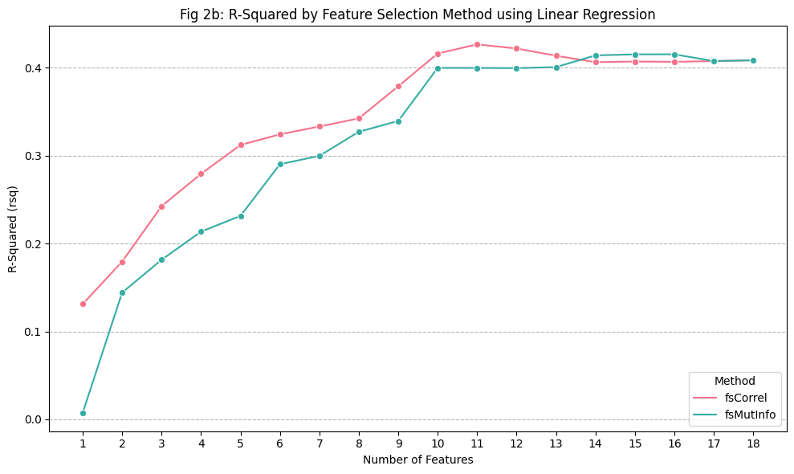

```python
# Task 2.1, Fig 2b
import pandas as pd
import numpy as np
from sklearn.linear_model import LinearRegression
from sklearn.metrics import r2_score
from sklearn.datasets import make_regression
from sklearn.model_selection import train_test_split
from sklearn.feature_selection import SelectKBest, f_regression, mutual_info_regression
import seaborn as sns
import matplotlib.pyplot as plt

# DEF FUN EVAL MODEL
def evaluate_model(X_train, y_train, X_test, y_test, method, k):
    # DEF feature selection
    X_train_fs, X_test_fs, fs = method(X_train, y_train, X_test, k)
    # FIT model
    model = LinearRegression()
    model.fit(X_train_fs, y_train)
    # REV model
    yhat = model.predict(X_test_fs)
    rsq = r2_score(y_test, yhat)
    return rsq

# DEF FUN FS CR
def select_feat_Correl(X_train, y_train, X_test, k):
    # DEF feature selection
    fsCorrel = SelectKBest(score_func=f_regression, k=k)
    # GET relationship from training
    fsCorrel.fit(X_train, y_train)
    # TFR train input data
    X_train_fsCorrel = fsCorrel.transform(X_train)
    # TFR test input data
    X_test_fsCorrel = fsCorrel.transform(X_test)
    return X_train_fsCorrel, X_test_fsCorrel, fsCorrel

# DEF FUN FS MI
def select_features_mutInfo(X_train, y_train, X_test, k):
    # DEF feature selection
    fsMutInfo = SelectKBest(score_func=mutual_info_regression, k=k)
    # GET relationship from training data
    fsMutInfo.fit(X_train, y_train)
    # TFR train input data
    X_train_fsMutInfo = fsMutInfo.transform(X_train)
    # TFR test input data
    X_test_fsMutInfo = fsMutInfo.transform(X_test)
    return X_train_fsMutInfo, X_test_fsMutInfo, fsMutInfo

# DEF df for results
results_df_rsq_by_feature = pd.DataFrame(columns=['Method', 'Features', 'rsq'])

for k in range(1, 19):  # LOOP THRU: 1 to 18
    # EVAL FS CR
    rsq_correl = evaluate_model(X_train, y_train, X_test, y_test, select_feat_Correl, k)
    results_df_rsq_by_feature = results_df_rsq_by_feature.append({'Method': 'fsCorrel', 'Features': k, 'rsq': rsq_correl}, ignore_index=True)
    # EVAL FS MI
    rsq_mutinfo = evaluate_model(X_train, y_train, X_test, y_test, select_features_mutInfo, k)
    results_df_rsq_by_feature = results_df_rsq_by_feature.append({'Method': 'fsMutInfo', 'Features': k, 'rsq': rsq_mutinfo}, ignore_index=True)

# DEF 'Method' and 'Features'
results_df_rsq_by_feature = results_df_rsq_by_feature.sort_values(by=['Method', 'Features'])

# DEF cust palette
custom_palette = sns.color_palette("husl", n_colors=2)

# VIS
fig, ax1 = pyplot.subplots(figsize=(10, 6))
sns.lineplot(data=results_df_rsq_by_feature, x='Features', y='rsq', hue='Method', palette=custom_palette, marker='o', ax=ax1)
ax1.set_xlabel('Number of Features')
ax1.set_ylabel('R-Squared (rsq)')
ax1.set_title('Fig 2b: R-Squared by Feature Selection Method using Linear Regression')
ax1.set_xticks(np.arange(1, 19))
ax1.grid(axis='y', linestyle='--', alpha=0.9)
ax1.legend(title='Method',loc='lower right')

pyplot.tight_layout()
pyplot.show()
```

```python
# Task 2.1: Feature Selection ALL

import numpy as np
import pandas as pd
from sklearn.linear_model import LinearRegression
from sklearn.tree import DecisionTreeRegressor
from sklearn.ensemble import RandomForestRegressor, GradientBoostingRegressor
from sklearn.metrics import mean_absolute_error, r2_score
from sklearn.feature_selection import SelectKBest, f_regression, mutual_info_regression

# DEF Function: correlation-based FS
def select_features_correl(X_train, y_train, X_test, k):
    fsCorrel = SelectKBest(score_func=f_regression, k=k)
    fsCorrel.fit(X_train, y_train)
    X_train_fsCorrel = fsCorrel.transform(X_train)
    X_test_fsCorrel = fsCorrel.transform(X_test)
    return X_train_fsCorrel, X_test_fsCorrel

# DEF Function: mutual information-based FS
def select_features_mutual(X_train, y_train, X_test, k):
    fsMutInfo = SelectKBest(score_func=mutual_info_regression, k=k)
    fsMutInfo.fit(X_train, y_train)
    X_train_fsMutInfo = fsMutInfo.transform(X_train)
    X_test_fsMutInfo = fsMutInfo.transform(X_test)
    return X_train_fsMutInfo, X_test_fsMutInfo

# SET models
ln_model = LinearRegression(random_state=21)
dt_model = DecisionTreeRegressor(random_state=21)
rf_model = RandomForestRegressor(random_state=21)
gb_model = GradientBoostingRegressor(random_state=21)

# DEF N of feat to consider
k_features_range = range(1, 19)  # RANGE values from 1 to 18

# SET an empty list to store the results
results = []

# RUN through each N of k_features
for k in k_features_range:
    # GET correlation-based FS
    X_train_fsCorrel, X_test_fsCorrel = select_features_correl(X_train, y_train, X_test, k)

    # GET models to iterate over
    models = [ln_model, dt_model, rf_model, gb_model]
    model_names = ['Linear', 'Decision Tree', 'Random Forest', 'Gradient Boosting']

    # FIT models and calc R-squared values for correlation-based
    for model, model_name in zip(models, model_names):
        model.fit(X_train_fsCorrel, y_train)
        y_pred = model.predict(X_test_fsCorrel)
        r2 = r2_score(y_test, y_pred)
        mae = mean_absolute_error(y_test, y_pred)
        # ADD result to the list
        results.append({
            'Regression Type': model_name,
            'Feature Selection Method': 'Correlation',
            'Number of Features': k,
            'R-squared': r2,
            'Mean Abs Err':mae
        })

    # GET mutual information-based FS
    X_train_fsMutInfo, X_test_fsMutInfo = select_features_mutual(X_train, y_train, X_test, k)

    # FIT models and calc R-squared values for mutual information-based
    for model, model_name in zip(models, model_names):
        model.fit(X_train_fsMutInfo, y_train)
        y_pred = model.predict(X_test_fsMutInfo)
        r2 = r2_score(y_test, y_pred)
        mae = mean_absolute_error(y_test, y_pred)
        # ADD result to the list
        results.append({
            'Regression Type': model_name,
            'Feature Selection Method': 'Mutual Information',
            'Number of Features': k,
            'R-squared': r2,
            'Mean Abs Err':mae
        })

# # DEF DataFrame to store the results
results_comp = pd.DataFrame(results)

# ORG the DataFrame by R-squared in descending order
results_comp = results_comp.sort_values(by='R-squared', ascending=False)

# REM negative values out
results_comp = results_comp[results_comp['R-squared'] > 0]
```

#### Part 2.1.5: Reviewing All Models and FS Methods by RSQ

Figure 3 illustrates the relative relationships between each regression model (and FS method) across the full range of features by RSQ and notes an overall positive initial trend hitting diminishing returns for all non DT models.

The DT models underperform somewhat comprehensively, failing to breach an RSQ of 30% at any poinnt.

The GB, RF, and LN models all ultimately climb in RSQ from 1 to 10 de-identified features, with most coming to rest (at 18 features) not far from where they sit at 10 features. The two highest scoring models are RF+MI and GB+CR.

***From this point the two models whose RSQ warrant further testing and cross-validation are the RF+MI and GB+CR models. The full set of resuts is indexed in Appendix C.***

```python
# Part 2.1.5 Reviewing Best Result by RSQ
print(results_comp.sort_values('R-squared',ascending=False).head(10))
```

```
       Regression Type Feature Selection Method  Number of Features  \
126      Random Forest       Mutual Information                  16
83   Gradient Boosting              Correlation                  11
118      Random Forest       Mutual Information                  15
110      Random Forest       Mutual Information                  14
75   Gradient Boosting              Correlation                  10
142      Random Forest       Mutual Information                  18
138      Random Forest              Correlation                  18
102      Random Forest       Mutual Information                  13
134      Random Forest       Mutual Information                  17
80              Linear              Correlation                  11

     R-squared  Mean Abs Err
126   0.464443      3.764012
83    0.455154      3.928863
118   0.453028      3.817165
110   0.446119      3.783694
75    0.433112      4.002464
142   0.432541      3.913188
138   0.432541      3.913188
102   0.432540      3.928647
134   0.431009      3.926835
80    0.426679      4.192936
```

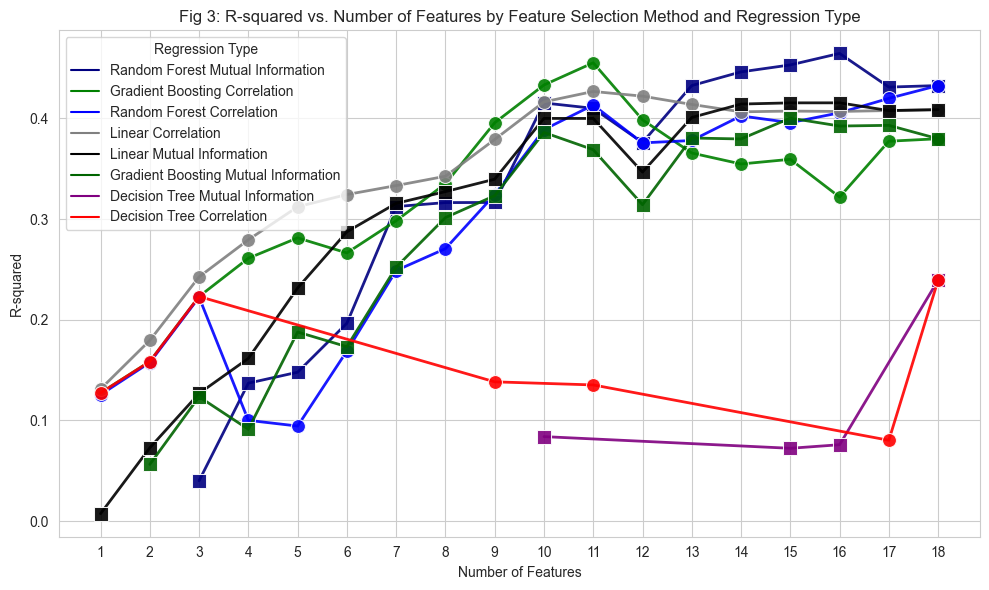

```python
# Fig 3: R-squared vs. Number of Features by Feature Selection Method and Regression Type
import numpy as np
import pandas as pd
import seaborn as sns
import matplotlib.pyplot as plt
# DEF color and marker styles
color_palette = {
    'Linear Mutual Information': 'black',
    'Decision Tree Mutual Information': 'purple',
    'Random Forest Mutual Information': 'navy',
    'Gradient Boosting Mutual Information': 'darkgreen',
    'Linear Correlation': 'grey',
    'Decision Tree Correlation': 'red',
    'Random Forest Correlation': 'blue',
    'Gradient Boosting Correlation': 'green'
}

# DEF  marker styles for each combination of regression type and feature selection method
marker_styles = {
    'Linear Mutual Information': 's',
    'Decision Tree Mutual Information': 's',
    'Random Forest Mutual Information': 's',
    'Gradient Boosting Mutual Information': 's',
    'Linear Correlation': 'o',
    'Decision Tree Correlation': 'o',
    'Random Forest Correlation': 'o',
    'Gradient Boosting Correlation': 'o'
}

# DEF a new column in the DataFrame for legend labels
results_comp['Legend'] = results_comp['Regression Type'] + ' ' + results_comp['Feature Selection Method']

# VIS results: separating line plots for each combination of regression type and FS method
sns.set_style('whitegrid')
pyplot.figure(figsize=(10, 6))
# DEF separate line plots for each combination of regression type and feature selection method
for legend_value in results_comp['Legend'].unique():
    df_subset = results_comp[results_comp['Legend'] == legend_value]
    regression_type, feature_selection_method = legend_value.split(' ', 1)
    sns.lineplot(data=df_subset, x='Number of Features', y='R-squared', hue='Legend', palette=color_palette,
                 marker=marker_styles[legend_value], markers=True, markersize=10, alpha=0.9, lw=2)

pyplot.title('Fig 3: R-squared vs. Number of Features by Feature Selection Method and Regression Type')
pyplot.xlabel('Number of Features')
pyplot.ylabel('R-squared')
pyplot.legend(title='Regression Type', markerscale=1.5, loc='upper left')
pyplot.xticks(np.arange(1, 19), np.arange(1, 19, 1).astype(int))  # SET integer values for x-axis
pyplot.tight_layout()
pyplot.show()
```

### Part 2.2: Fine tuning and Performance Analysis

Random Forest and Gradient Boosting regressions have each been cross-paired with randomized and grid search cross-validation methods as well as cv-scoring to provide a three-way review on both RF + MI and GB + CR models. Utilising three models for each intends to derive a consensus opinion towards how each model scores as benchmarked against their optimal search results above.

The randomized search method offers a less computationally intensive approach, whereas the grid-search offers a more comprehensive brute force which is not unreasonable given the limited data size which is more accessible due to the lower numer of samples in the data.

The cross-validation here-in utilised the optimal number of features as discovered above.

```python
from sklearn.feature_selection import SelectKBest, mutual_info_regression
from sklearn.ensemble import RandomForestRegressor
from sklearn.metrics import mean_absolute_error, r2_score
import numpy as np
import pandas as pd


# DEF BEST RF+MI MODEL AT 16 FEATURES

kCVTestRF=16

# DEF Function: mutual information-based feature selection
def select_features_mutual(X_train, y_train, X_test, k):
    fsMutInfo = SelectKBest(score_func=mutual_info_regression, k=kCVTestRF)
    fsMutInfo.fit(X_train, y_train)
    X_train_fsMutInfo = fsMutInfo.transform(X_train)
    X_test_fsMutInfo = fsMutInfo.transform(X_test)
    return X_train_fsMutInfo, X_test_fsMutInfo

# FS for MI
X_train_fsMutInfo, X_test_fsMutInfo = select_features_mutual(X_train, y_train, X_test, k=kCVTestRF)
# FIT model
model = RandomForestRegressor(random_state=21)
model.fit(X_train_fsMutInfo, y_train)
# REV model
y_pred_rf_mi = model.predict(X_test_fsMutInfo)
# REV predictions
maeMutInfo = mean_absolute_error(y_test, y_pred_rf_mi)
rsqMutInfo = r2_score(y_test, y_pred_rf_mi)

# GET feature importances for RF + MI model
def get_feature_importances(X_train, y_train, k):
    fsMutInfo = SelectKBest(score_func=mutual_info_regression, k=k)
    fsMutInfo.fit(X_train, y_train)

    if isinstance(X_train, np.ndarray):
        feature_importances = dict(zip(range(X_train.shape[1]), fsMutInfo.scores_))
    else:
        feature_importances = dict(zip(X_train.columns, fsMutInfo.scores_))

    return feature_importances

feature_importances_rf_mi = get_feature_importances(X_train, y_train, kCVTestRF)

# DEF a dataframe from the feature importances dictionary
rf_mi_feat_imp = pd.DataFrame(feature_importances_rf_mi.items(), columns=["FeatureIndex", "Importance_rf_mi"])

# SET pairs the features up by index with custom_labels
rf_mi_feat_imp['Feature'] = [custom_labels[idx] for idx in rf_mi_feat_imp['FeatureIndex']]

# ORG df by dropping Featureindex
rf_mi_feat_imp.drop(columns=["FeatureIndex"], inplace=True)
```

```python
#Task 2.2.1 Model Performance Comparison for RF+MI w/GridSearchCV
# LIBRARIES
from sklearn.ensemble import RandomForestRegressor
from sklearn.model_selection import GridSearchCV
from sklearn.metrics import mean_absolute_error

# DEF MODEL
model_rf = RandomForestRegressor()

# DEF Hyperparameter Tuning w/ GridSearchCV
param_grid_rf = {
    'n_estimators': [50, 100, 150],
    'max_depth': [None, 10, 20, 30],
    'min_samples_split': [2, 5, 10],
    'min_samples_leaf': [1, 2, 4],
    'bootstrap': [True, False]
    }

# DEF GS CV METHOD
grid_search_rf = GridSearchCV(estimator=model_rf, param_grid=param_grid_rf, cv=5, n_jobs=-2)
grid_search_rf.fit(X_train_fsMutInfo, y_train)

# REV Model MAE + RSQ
best_model_rf_gs = grid_search_rf.best_estimator_
y_pred_rf_gs = best_model_rf_gs.predict(X_test_fsMutInfo)
mae_rf_gs = mean_absolute_error(y_test, y_pred_rf_gs)
r2_rf_gs = r2_score(y_test, y_pred_rf_gs)

# DEF Final Model and selected features
final_model_rf_gs = best_model_rf_gs
final_model_rf_gs.fit(X_train_fsMutInfo, y_train)
y_pred_final_rf_gs = final_model_rf_gs.predict(X_test_fsMutInfo)

# REV best_model_rf obtained from GridSearchCV
best_features_rf_gs = best_model_rf_gs.feature_importances_
feature_importance_rf_gs = dict(zip(X_encoded.columns, best_features_rf_gs))
sorted_feature_importance_rf_gs = sorted(feature_importance_rf_gs.items(), key=lambda x: x[1], reverse=True)
```

#### Part 2.2.1: Random Forest Cross-Validation: Grid Search

The iteration of this model with grid search cross validtion revealed a relatively higher MAE and lower RSQ values indicating a lower rate of performance to the best model benchmark which returned MAE (~3.764) and RSQ (~46.444%).

The best features are output below with 5 of the top 10 relating to financial risk, and the rest being 4 sector categories and the controversy level.

```python
print('MAE using Random Forest Regression with Grid Search CV:', round(mae_rf_gs,3))
print('RSQ using Random Forest Regression with Grid Search CV:', round(100*r2_rf_gs,3))
print("Random Forest Regression (GridSearchCV) - Best Features:")
for feature, importance in sorted_feature_importance_rf_gs:
    print(f"{feature}: {importance:.3f}")
```

```
MAE using Random Forest Regression with Grid Search CV: 3.884
RSQ using Random Forest Regression with Grid Search CV: 43.881
Random Forest Regression (GridSearchCV) - Best Features:
EPS: 0.140
StDev_3y: 0.129
StDev_1y: 0.122
Sector_Information Technology: 0.119
Beta: 0.078
ControversyLevel: 0.072
Sector_Consumer Discretionary: 0.071
MarketCap: 0.070
Sector_Health Care: 0.058
Sector_Materials: 0.056
Sector_Financials: 0.022
LnRet_1y: 0.019
Sector_Industrials: 0.015
Sector_Consumer Staples: 0.013
LnRet_3y: 0.008
Sector_Energy: 0.007
```

```python
#Task 2.2.2 Model Performance Comparison for RF+MI w/RandomizedSearchCV

from sklearn.ensemble import RandomForestRegressor
from sklearn.model_selection import RandomizedSearchCV
from sklearn.metrics import mean_absolute_error

# DEF MODEL
model_rf = RandomForestRegressor()

# DEF Hyperparameter Tuning w/ GridSearchCV
param_rnds_rf = {
    'n_estimators': [50, 100, 150],
    'max_depth': [None, 10, 20, 30],
    'min_samples_split': [2, 5, 10],
    'min_samples_leaf': [1, 2, 4],
    'bootstrap': [True, False]
    }

# DEF RS CV METHOD
random_search_rf = RandomizedSearchCV(estimator=model_rf, param_distributions=param_rnds_rf, cv=5, n_jobs=-2)
random_search_rf.fit(X_train_fsMutInfo, y_train)

# REV Model MAE + RSQ
best_model_rf_rs = random_search_rf.best_estimator_
y_pred_rf_rs = best_model_rf_rs.predict(X_test_fsMutInfo)
mae_rf_rs = mean_absolute_error(y_test, y_pred_rf_rs)
r2_rf_rs = r2_score(y_test, y_pred_rf_rs)

# DEF Final Model and selected features
final_model_rf_rs = best_model_rf_rs
final_model_rf_rs.fit(X_train_fsMutInfo, y_train)
y_pred_final_rf_rs = final_model_rf_rs.predict(X_test_fsMutInfo)

# REV best_model_rf obtained from GridSearchCV
best_features_rf_rs = best_model_rf_rs.feature_importances_
feature_importance_rf_rs = dict(zip(X_encoded.columns, best_features_rf_rs))
sorted_feature_importance_rf_rs = sorted(feature_importance_rf_rs.items(), key=lambda x: x[1], reverse=True)
```

#### Part 2.2.2: Random Forest Cross-Validation: Random Search

The best features are output below with 5 of the top 10 features being financial risk measurements. 4 sector categoies and Controversy Level filled out the top 10.

```python
print('MAE using Random Forest Regression with Randomized Search CV:',  round(mae_rf_rs,3))
print('RSQ using Random Forest Regression with Randomized Search CV:', round(100*r2_rf_rs,3))
print('N Features selected: ',len(sorted_feature_importance_rf_rs))

print("Random Forest Regression (RandomizedSearchCV) - Best Features:")
for feature, importance in sorted_feature_importance_rf_rs:
    print(f"{feature}: {importance:.3f}")
```

```
MAE using Random Forest Regression with Randomized Search CV: 3.884
RSQ using Random Forest Regression with Randomized Search CV: 43.377
N Features selected:  16
Random Forest Regression (RandomizedSearchCV) - Best Features:
StDev_3y: 0.140
EPS: 0.139
Sector_Information Technology: 0.109
StDev_1y: 0.106
Sector_Consumer Discretionary: 0.086
MarketCap: 0.076
Beta: 0.071
ControversyLevel: 0.069
Sector_Health Care: 0.063
Sector_Materials: 0.054
Sector_Financials: 0.025
LnRet_1y: 0.019
Sector_Industrials: 0.018
LnRet_3y: 0.011
Sector_Consumer Staples: 0.007
Sector_Energy: 0.007
```

```python
# DEF OPTIMAL N FEAT FOR GB + CR

kCVTestGB = 11

# DEF FUN CR FS
def select_features_correl(X_train, y_train, X_test, k):
    fsCorrel = SelectKBest(score_func=f_regression, k=k)
    fsCorrel.fit(X_train, y_train)
    X_train_fsCorrel = fsCorrel.transform(X_train)
    X_test_fsCorrel = fsCorrel.transform(X_test)
    return X_train_fsCorrel, X_test_fsCorrel

X_train_fsCorrel, X_test_fsCorrel = select_features_correl(X_train, y_train, X_test, k=kCVTestGB)

gb_model = GradientBoostingRegressor(random_state=21)

gb_model.fit(X_train_fsCorrel, y_train)
# REV model
y_pred_gb_cr = gb_model.predict(X_test_fsCorrel)
# REV predictions
maeCorrel = mean_absolute_error(y_test, y_pred_gb_cr)
rsqCorrel = r2_score(y_test, y_pred_gb_cr)

# Get feature importances for GB + CR model
def get_feature_importances(X_train, y_train, k):
    fsCorrel = SelectKBest(score_func=mutual_info_regression, k=k)
    fsCorrel.fit(X_train, y_train)

    if isinstance(X_train, np.ndarray):
        feature_importances = dict(zip(range(X_train.shape[1]), fsCorrel.scores_))
    else:
        feature_importances = dict(zip(X_train.columns, fsCorrel.scores_))

    return feature_importances

feature_importances_gb_cr = get_feature_importances(X_train, y_train, kCVTestRF)

# Create a dataframe from the feature importances dictionary
gb_cr_feat_imp = pd.DataFrame(feature_importances_gb_cr.items(), columns=["FeatureIndex", "Importance_gb_cr"])

# Pair the features up by index with custom_labels
gb_cr_feat_imp['Feature'] = [custom_labels[idx] for idx in gb_cr_feat_imp['FeatureIndex']]

# ORG df by dropping Featureindex
gb_cr_feat_imp.drop(columns=["FeatureIndex"], inplace=True)
```

```python
#Task 2.2.3 Model Performance Comparison for Gradient Boosting + Correlation Feature Selection
# LIBRARIES
from sklearn.ensemble import GradientBoostingRegressor
from sklearn.model_selection import GridSearchCV
from sklearn.metrics import mean_absolute_error, r2_score

# DEF MODEL
model_gb = GradientBoostingRegressor()

# DEF Hyperparameter Tuning w/ GridSearchCV
param_grid_gb = {
    'n_estimators': [50, 100, 150],
    'learning_rate': [0.1, 0.05, 0.01],
    'max_depth': [3, 5, 7],
    'min_samples_split': [2, 5, 10],
    'min_samples_leaf': [1, 2, 4]
}

# DEF GS CV METHOD
grid_search_gb = GridSearchCV(estimator=model_gb, param_grid=param_grid_gb, cv=5, n_jobs=-2)
grid_search_gb.fit(X_train_fsCorrel, y_train)

# REV Model MAE + RSQ
best_model_gb_gs = grid_search_gb.best_estimator_
y_pred_gb_gs = best_model_gb_gs.predict(X_test_fsCorrel)
mae_gb_gs = mean_absolute_error(y_test, y_pred_gb_gs)
r2_gb_gs = r2_score(y_test, y_pred_gb_gs)

# DEF Final Model and selected features
final_model_gb_gs = best_model_gb_gs
final_model_gb_gs.fit(X_train_fsCorrel, y_train)
y_pred_final_gb = final_model_gb_gs.predict(X_test_fsCorrel)

# REV best_model_gb obtained from GridSearchCV
best_features_gb_gs = best_model_gb_gs.feature_importances_
feature_importance_gb_gs = dict(zip(X_encoded.columns, best_features_gb_gs))
sorted_feature_importance_gb_gs = sorted(feature_importance_gb_gs.items(), key=lambda x: x[1], reverse=True)
```

#### Part 2.2.3: Gradient Boosting Cross-Validation: Grid Search

The best features are output below with 7 of the top 10 relating to financial risk, and 2 sector categories and the controversy level.

```python
print('MAE using Gradient Boosting Regression with Grid Search CV:',  round(mae_gb_gs,3))
print('RSQ using Gradient Boosting Regression with Grid Search CV:', round(100*r2_gb_gs,3))
print('N Features selected: ',len(sorted_feature_importance_gb_gs))

print("Gradient Boosting Regression (GridSearchCV) - Best Features:")
for feature, importance in sorted_feature_importance_gb_gs:
    print(f"{feature}: {importance:.3f}")
```

```
MAE using Gradient Boosting Regression with Grid Search CV: 4.034
RSQ using Gradient Boosting Regression with Grid Search CV: 41.868
N Features selected:  11
Gradient Boosting Regression (GridSearchCV) - Best Features:
MarketCap: 0.214
Beta: 0.139
Sector_Consumer Staples: 0.132
StDev_3y: 0.126
Sector_Energy: 0.093
ControversyLevel: 0.090
LnRet_3y: 0.088
LnRet_1y: 0.038
EPS: 0.033
StDev_1y: 0.024
Sector_Consumer Discretionary: 0.022
```

```python
#Task 2.2.4 Model Performance Comparison for Gradient Boosting + Correlation Feature Selection
# LIBRARIES
from sklearn.ensemble import GradientBoostingRegressor
from sklearn.model_selection import RandomizedSearchCV
from sklearn.metrics import mean_absolute_error, r2_score

# DEF MODEL
model_gb = GradientBoostingRegressor()

# DEF Hyperparameter Tuning w/ RandomizedSearchCV
param_grid_gb = {
    'n_estimators': [50, 100, 150],
    'learning_rate': [0.1, 0.05, 0.01],
    'max_depth': [3, 5, 7],
    'min_samples_split': [2, 5, 10],
    'min_samples_leaf': [1, 2, 4]
}

# DEF GS CV METHOD
grid_search_gb = GridSearchCV(estimator=model_gb, param_grid=param_grid_gb, cv=5, n_jobs=-2)
grid_search_gb.fit(X_train_fsCorrel, y_train)

# REV Model MAE + RSQ
best_model_gb_rs = grid_search_gb.best_estimator_
y_pred_gb_rs = best_model_gb_rs.predict(X_test_fsCorrel)
mae_gb_rs = mean_absolute_error(y_test, y_pred_gb_rs)
r2_gb_rs = r2_score(y_test, y_pred_gb_rs)

# DEF Final Model and selected features
final_model_gb_rs = best_model_gb_rs
final_model_gb_rs.fit(X_train_fsCorrel, y_train)
y_pred_final_gb = final_model_gb_rs.predict(X_test_fsCorrel)

# REV best_model_gb obtained from GridSearchCV
best_features_gb_rs = best_model_gb_rs.feature_importances_
feature_importance_gb_rs = dict(zip(X_encoded.columns, best_features_gb_rs))
sorted_feature_importance_gb_rs = sorted(feature_importance_gb_rs.items(), key=lambda x: x[1], reverse=True)
```

The best features are output below with 7 of the top 10 features being financial risk measurements. 2 sector categoies and Controversy Level rounded out the top 10.

```python
print('MAE using Gradient Boosting Regression with Randomized Search CV:',  round(mae_gb_rs,3))
print('RSQ using Gradient Boosting Regression with Randomized Search CV:', round(100*r2_gb_rs,3))
print('N Features selected: ',len(sorted_feature_importance_gb_rs))

print("Random Forest Regression (RandomizedSearchCV) - Best Features:")
for feature, importance in sorted_feature_importance_gb_rs:
    print(f"{feature}: {importance:.3f}")
```

```
MAE using Gradient Boosting Regression with Randomized Search CV: 4.034
RSQ using Gradient Boosting Regression with Randomized Search CV: 41.868
N Features selected:  11
Random Forest Regression (RandomizedSearchCV) - Best Features:
MarketCap: 0.214
Beta: 0.139
Sector_Consumer Staples: 0.132
StDev_3y: 0.126
Sector_Energy: 0.093
ControversyLevel: 0.090
LnRet_3y: 0.088
LnRet_1y: 0.038
EPS: 0.033
StDev_1y: 0.024
Sector_Consumer Discretionary: 0.022
```

```python
# DEF ALL DF
# rf_mi_feat_imp = pd.DataFrame(rf_mi_feat_imp,columns = ['Importance_rf_mi','Feature'])
rf_mi_feat_imp = rf_mi_feat_imp.reindex(columns = ['Feature','Importance_rf_mi'])
rf_gs_feat_imp = pd.DataFrame(sorted_feature_importance_rf_gs,columns=['Feature','Importance_rf_gs'])
rf_rs_feat_imp = pd.DataFrame(sorted_feature_importance_rf_rs,columns=['Feature','Importance_rf_rs'])
# JOIN
rf_feat_ALL = rf_mi_feat_imp
rf_feat_ALL = rf_mi_feat_imp.merge(rf_gs_feat_imp, on='Feature', how='inner')
rf_feat_ALL = rf_feat_ALL.merge(rf_rs_feat_imp, on='Feature', how='inner')
```

```python
# DEF ALL DF
gb_cr_feat_imp = gb_cr_feat_imp.reindex(columns = ['Feature','Importance_gb_cr'])
gb_gs_feat_imp = pd.DataFrame(sorted_feature_importance_gb_gs,columns=['Feature','Importance_gb_gs'])
gb_rs_feat_imp = pd.DataFrame(sorted_feature_importance_gb_rs,columns=['Feature','Importance_gb_rs'])
# JOIN
gb_feat_ALL = gb_cr_feat_imp
gb_feat_ALL = gb_feat_ALL.merge(gb_gs_feat_imp,on='Feature', how='inner')
gb_feat_ALL = gb_feat_ALL.merge(gb_rs_feat_imp,on='Feature', how='inner')
```

```python
import pandas as pd
import matplotlib.pyplot as plt
import numpy as np

# GET the column names to check if 'Feature' is present
print(gb_feat_ALL.columns)

# REV if 'Feature' is present in the columns
if 'Feature' in gb_feat_ALL.columns:
    # SET the 'Feature' column as the index
    gb_feat_ALL.set_index('Feature', inplace=True)
else:
    print("Error: 'Feature' column not found in DataFrame.")
    exit()

# DEF array of x-positions for sets of bars
bar_width = 0.2  # Width of each bar
x = np.arange(len(gb_feat_ALL.index))  # Index array for the features
x_gb_cr = x - bar_width
x_gb_gs = x
x_gb_rs = x + bar_width
```

```
Index(['Feature', 'Importance_gb_cr', 'Importance_gb_gs', 'Importance_gb_rs'], dtype='object')
```

#### Part 2.2.5: Visualising Relative Feature Importance: Gradient Boosting

Figure 4a contrasts the 11 features identified in the earlier selection process (Part 2.1) for this model. It is noted that there are two features which have a minimal importance in the correlation model, which have been found to be more important in the cv process, relative to the correlation process.

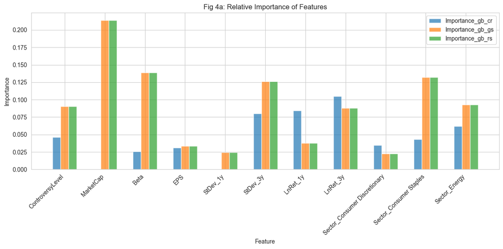

```python
# ORG graph the data
pyplot.figure(figsize=(12, 6))  # Adjust the figure size as needed
pyplot.bar(x_gb_cr, gb_feat_ALL['Importance_gb_cr'], width=bar_width, label='Importance_gb_cr', alpha=0.7)
pyplot.bar(x_gb_gs, gb_feat_ALL['Importance_gb_gs'], width=bar_width, label='Importance_gb_gs', alpha=0.7)
pyplot.bar(x_gb_rs, gb_feat_ALL['Importance_gb_rs'], width=bar_width, label='Importance_gb_rs', alpha=0.7)

# ORG plot feat
pyplot.xlabel('Feature')
pyplot.ylabel('Importance')
pyplot.title('Fig 4a: Relative Importance of Features')
pyplot.legend()

# SET x-axis labels to show the feature names
pyplot.xticks(x, gb_feat_ALL.index, rotation=45, ha='right')

# VIS the plot
pyplot.tight_layout()
pyplot.show()
```

```python
import pandas as pd
import matplotlib.pyplot as plt
import numpy as np

# GET column names to check if 'Feature' is present
print(rf_feat_ALL.columns)

if 'Feature' in rf_feat_ALL.columns:
    # SET 'Feature' column as index
    rf_feat_ALL.set_index('Feature', inplace=True)
else:
    print("Error: 'Feature' column not found in DataFrame.")
    exit()

# DEF array of x-positions sets of bars
bar_width = 0.2  # Width of each bar
x = np.arange(len(rf_feat_ALL.index))  # Index array for the features
x_rf_mi = x - bar_width
x_rf_gs = x
x_rf_rs = x + bar_width
```

```
Index(['Feature', 'Importance_rf_mi', 'Importance_rf_gs', 'Importance_rf_rs'], dtype='object')
```

#### Part 2.2.6: Visualising Relative Feature Importance: Random Forest

Figure 4b contrasts the 16 features identified in the earlier selection process (Part 2.1) for this model.

It is noted that the cv process again amplifies 3 features who scored to have a negligible importance in the mutual information feature selection method. Four features that amounted to a significant showing in the RF+MI model were suppressed in the CV stage to quite some scale.

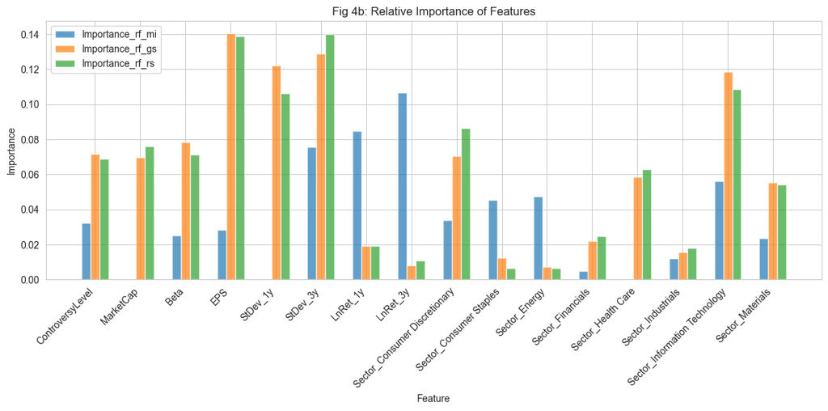

```python
# ORG plot for data
pyplot.figure(figsize=(12, 6))  # Adjust the figure size as needed
pyplot.bar(x_rf_mi, rf_feat_ALL['Importance_rf_mi'], width=bar_width, label='Importance_rf_mi', alpha=0.7)
pyplot.bar(x_rf_gs, rf_feat_ALL['Importance_rf_gs'], width=bar_width, label='Importance_rf_gs', alpha=0.7)
pyplot.bar(x_rf_rs, rf_feat_ALL['Importance_rf_rs'], width=bar_width, label='Importance_rf_rs', alpha=0.7)

# ORG plot features
pyplot.xlabel('Feature')
pyplot.ylabel('Importance')
pyplot.title('Fig 4b: Relative Importance of Features')
pyplot.legend()

# SET x-axis labels as feature names
pyplot.xticks(x, rf_feat_ALL.index, rotation=45, ha='right')

# VIS plot
pyplot.tight_layout()
pyplot.show()
```

```python
# Part 2.2.7: Summary Table
import pandas as pd

rfBenchmark = results_comp.drop(['Legend'],axis=1)
# df = df.drop(['LastUpdateDate'], axis=1)

rfBenchmark = rfBenchmark[
    (rfBenchmark['Feature Selection Method'] == 'Mutual Information') &
    (rfBenchmark['Regression Type'] == 'Random Forest')]
rfBenchmark = rfBenchmark[
    (rfBenchmark['Number of Features'] == 16)]

gbBenchmark = results_comp
gbBenchmark = gbBenchmark[
    (gbBenchmark['Feature Selection Method'] == 'Correlation') &
    (gbBenchmark['Regression Type'] == 'Gradient Boosting')]
gbBenchmark = gbBenchmark[
    (gbBenchmark['Number of Features'] == 11)]

# SET list of dictionaries for the new entries
new_entries = [
    {'Regression Type': 'Gradient Boosting',
     'Feature Selection Method': 'Grid Search CV',
     'Number of Features': 11,
     'R-squared': r2_gb_gs,
     'Mean Abs Err': mae_gb_gs},
    {'Regression Type': 'Gradient Boosting',
     'Feature Selection Method': 'Randomized Search CV',
     'Number of Features': 11,
     'R-squared': r2_gb_rs,
     'Mean Abs Err': mae_gb_rs},
    {'Regression Type': 'Random Forest',
     'Feature Selection Method': 'Grid Search CV',
     'Number of Features': 16,
     'R-squared': r2_rf_gs,
     'Mean Abs Err': mae_rf_gs},
    {'Regression Type': 'Random Forest',
     'Feature Selection Method': 'Randomized Search CV',
     'Number of Features': 16,
     'R-squared': r2_rf_rs,
     'Mean Abs Err': mae_rf_rs}
     ]


# APP new entries to the cvBenchmark df
cvBenchmark = rfBenchmark.append(gbBenchmark, ignore_index=True)
cvBenchmark = cvBenchmark.append(new_entries, ignore_index=True)

cvBenchmark['R-squared Rank'] = cvBenchmark['R-squared'].rank(ascending=False)
cvBenchmark['MAE Rank'] = cvBenchmark['Mean Abs Err'].rank()
cvBenchmark
```

|  | Regression Type | Feature Selection Method | Number of Features | R-squared | Mean Abs Err | Legend | R-squared Rank | MAE Rank |
| --- | --- | --- | --- | --- | --- | --- | --- | --- |
| 0 | Random Forest | Mutual Information | 16 | 0.464443 | 3.764012 | NaN | 1.0 | 1.0 |
| 1 | Gradient Boosting | Correlation | 11 | 0.455154 | 3.928863 | Gradient Boosting Correlation | 2.0 | 4.0 |
| 2 | Gradient Boosting | Grid Search CV | 11 | 0.418683 | 4.034341 | NaN | 5.5 | 5.5 |
| 3 | Gradient Boosting | Randomized Search CV | 11 | 0.418683 | 4.034341 | NaN | 5.5 | 5.5 |
| 4 | Random Forest | Grid Search CV | 16 | 0.438814 | 3.884347 | NaN | 3.0 | 3.0 |
| 5 | Random Forest | Randomized Search CV | 16 | 0.433770 | 3.883681 | NaN | 4.0 | 2.0 |

#### Part 2.2.7: Summary of Cross Validation Results

None of the above cross validation methods improved upon the benchmark scoring determined in Part 2.1 when using 5 folds. The models above are all tested on the best in class models against both Grid and Random searches.

The RF+MI model was the only model to have a CV result come close (RF+RS). The GB+CR model had a competitive RSQ (related to RF+MI) with fewer features and through the CV process all relative performance metrics were much grouped and much lower than the inital GB+CR model.

These comparisions are on a feature for feature basis and we will not be able to determine if Getting more performance from less features and a less sophisticated approach plays well with the principle of parsimony.

***The table below illustrates the performance rankings over both RSQ and MAE measures.***

```python
cvBenchmark.sort_values('R-squared Rank')
```

|  | Regression Type | Feature Selection Method | Number of Features | R-squared | Mean Abs Err | Legend | R-squared Rank | MAE Rank |
| --- | --- | --- | --- | --- | --- | --- | --- | --- |
| 0 | Random Forest | Mutual Information | 16 | 0.464443 | 3.764012 | NaN | 1.0 | 1.0 |
| 1 | Gradient Boosting | Correlation | 11 | 0.455154 | 3.928863 | Gradient Boosting Correlation | 2.0 | 4.0 |
| 4 | Random Forest | Grid Search CV | 16 | 0.438814 | 3.884347 | NaN | 3.0 | 3.0 |
| 5 | Random Forest | Randomized Search CV | 16 | 0.433770 | 3.883681 | NaN | 4.0 | 2.0 |
| 2 | Gradient Boosting | Grid Search CV | 11 | 0.418683 | 4.034341 | NaN | 5.5 | 5.5 |
| 3 | Gradient Boosting | Randomized Search CV | 11 | 0.418683 | 4.034341 | NaN | 5.5 | 5.5 |

### Part 2.3: Model Comparison

With feature selection and tuning complete, the models will be compared with paired t-tests as below. The purpose of this is to determine whether or not there is any statistically significant difference between the relative importance of scored features, and each models respective predictions.

```python
# Part 2.3 SETUP
import pandas as pd
from scipy.stats import ttest_rel
# DEF ALPHA
alpha = 0.05
```

```python
# DEF FUN FOR PAIR T TEST
import pandas as pd
from scipy.stats import ttest_rel

def paired_t_test(dataframe, col1, col2):
    alpha=0.05
    t_statistic, p_value = ttest_rel(dataframe[col1], dataframe[col2])
    p_value = round(p_value, 2)

    if p_value < alpha:
        print(f"Statistically significant difference between {col1} and {col2} with p-value: {p_value}")
    else:
        print(f"No statistically significant difference between {col1} and {col2} with p-value: {p_value}")
```

#### Part 2.3.1: Compare Random Forest CV Feature Importance

By using paired t-tests to compare the important features for both CV methods regarding the RF models there is;

```python
# Part 2.3.1: Compare CV Scores RF to see if sampling is different
rf_rs_FeatImp = pd.DataFrame(sorted_feature_importance_rf_rs, columns=['Feature', 'Importance rf_RS'])
rf_gs_FeatImp = pd.DataFrame(sorted_feature_importance_rf_gs, columns=['Feature', 'Importance rf_GS'])
rfComparision = pd.DataFrame(rf_rs_FeatImp.merge(rf_gs_FeatImp, on='Feature',how='outer').sort_values('Feature'))
# Paired t-test
paired_t_test(rfComparision,'Importance rf_RS','Importance rf_GS')
print(rfComparision.sort_index(ascending=True))
```

```
No statistically significant difference between Importance rf_RS and Importance rf_GS with p-value: 1.0
                          Feature  Importance rf_RS  Importance rf_GS
0                        StDev_3y          0.140185          0.129058
1                             EPS          0.138689          0.140426
2   Sector_Information Technology          0.108698          0.118697
3                        StDev_1y          0.106309          0.122157
4   Sector_Consumer Discretionary          0.086447          0.070691
5                       MarketCap          0.076066          0.069742
6                            Beta          0.071104          0.078269
7                ControversyLevel          0.069091          0.071806
8              Sector_Health Care          0.063102          0.058500
9                Sector_Materials          0.054107          0.055544
10              Sector_Financials          0.024771          0.022154
11                       LnRet_1y          0.019410          0.019353
12             Sector_Industrials          0.017941          0.015480
13                       LnRet_3y          0.010867          0.008247
14        Sector_Consumer Staples          0.006618          0.012547
15                  Sector_Energy          0.006593          0.007329
```

#### Part 2.3.2: Compare Gradient Boosting CV Feature Importance

By using paired t-tests to compare the important features for both CV methods regarding the GB models there is;

```python
# Part 2.3.2: Compare CV scores GB to see if sampling is different
# GET scores
gb_rs_FeatImp = pd.DataFrame(sorted_feature_importance_gb_rs, columns=['Feature', 'Importance GB_RS'])
gb_gs_FeatImp = pd.DataFrame(sorted_feature_importance_gb_gs, columns=['Feature', 'Importance GB_GS'])

gbComparision = gb_rs_FeatImp.merge(gb_gs_FeatImp, on='Feature',how='outer').sort_values('Feature')
# RUN Paired t-test
paired_t_test(gbComparision,'Importance GB_RS','Importance GB_GS')
print(gbComparision.sort_index(ascending=True))
```

```
No statistically significant difference between Importance GB_RS and Importance GB_GS with p-value: 1.0
                          Feature  Importance GB_RS  Importance GB_GS
0                       MarketCap          0.213824          0.213824
1                            Beta          0.138618          0.138830
2         Sector_Consumer Staples          0.132045          0.132045
3                        StDev_3y          0.126157          0.125945
4                   Sector_Energy          0.092849          0.092849
5                ControversyLevel          0.090500          0.090500
6                        LnRet_3y          0.088103          0.088103
7                        LnRet_1y          0.037879          0.037879
8                             EPS          0.033269          0.033269
9                        StDev_1y          0.024282          0.024282
10  Sector_Consumer Discretionary          0.022474          0.022474
```

#### Part 2.3.3: Comparing the Predictions of the Random Forest Model

Below the combined prediction results from the Random Forest models are combined and paired t-tests are conducted to determine what statistical significance there is on differences between the benchmark RF model and the CV.

```python
# Part 2.3.3: Compare Predictions between RF+MI and RF CV Scores SETUP
# GET scores
y_pred_rf_mi = pd.DataFrame(y_pred_rf_mi, columns=['Pred.RF_MI'])
y_pred_rf_gs = pd.DataFrame(y_pred_rf_gs, columns=['Pred.RF_GS'])
y_pred_rf_rs = pd.DataFrame(y_pred_rf_rs, columns=['Pred.RF_RS'])
# ORG df
y_pred_rf_ALL = y_pred_rf_mi.merge(y_pred_rf_gs,left_index=True, right_index=True)
y_pred_rf_ALL = y_pred_rf_ALL.merge(y_pred_rf_rs,left_index=True, right_index=True)
print(y_pred_rf_ALL)
# RUN paired t-test
paired_t_test(y_pred_rf_ALL,'Pred.RF_MI','Pred.RF_GS')
paired_t_test(y_pred_rf_ALL,'Pred.RF_MI','Pred.RF_RS')
print(y_pred_rf_ALL.sample(15).sort_index(ascending=True))
```

```
    Pred.RF_MI  Pred.RF_GS  Pred.RF_RS
0       11.452   11.845647   11.936925
1       17.662   18.568341   17.855785
2       24.506   24.722714   23.753072
3       24.113   23.819393   24.343542
4       18.757   19.518086   19.840676
..         ...         ...         ...
80      20.632   20.622362   20.797714
81      19.390   19.530767   19.358018
82      17.328   17.243284   17.764718
83      28.487   27.011528   27.551032
84      28.971   27.697235   28.131491

[85 rows x 3 columns]
No statistically significant difference between Pred.RF_MI and Pred.RF_GS with p-value: 0.41
```

[output cut: 17 more lines]

#### Part 2.3.4: Comparing the Predictions of the Gradient Boosting Model

Below the combined prediction results from the Gradient Boosting models are combined and paired t-tests are conducted to determine what statistical significance there is on differences between the benchmark RF model and the CV.

```python
# Part 2.3.4: Compare Predictions between GB+CR and GB CV Scores SETUP
# GET data for review
y_pred_gb_cr = pd.DataFrame(y_pred_gb_cr, columns=['Pred.GB_CR'])
y_pred_gb_gs = pd.DataFrame(y_pred_gb_gs, columns=['Pred.GB_GS'])
y_pred_gb_rs = pd.DataFrame(y_pred_gb_rs, columns=['Pred.GB_RS'])
# ORG df to rev
y_pred_gb_ALL = y_pred_gb_cr.merge(y_pred_gb_gs,left_index=True, right_index=True)
y_pred_gb_ALL = y_pred_gb_ALL.merge(y_pred_gb_rs,left_index=True, right_index=True)
paired_t_test(y_pred_gb_ALL,'Pred.GB_CR','Pred.GB_GS')
paired_t_test(y_pred_gb_ALL,'Pred.GB_CR','Pred.GB_GS')
print(y_pred_gb_ALL.sample(15).sort_index(ascending=True))
```

```
No statistically significant difference between Pred.GB_CR and Pred.GB_GS with p-value: 0.52
No statistically significant difference between Pred.GB_CR and Pred.GB_GS with p-value: 0.52
    Pred.GB_CR  Pred.GB_GS  Pred.GB_RS
2    22.107461   22.951465   22.951465
13   13.795645   16.442443   16.442443
18   20.505751   20.790942   20.790942
24   11.287988   12.054448   12.054448
29   13.125626   12.849494   12.849494
33   22.500795   22.951465   22.951465
39   19.470562   19.838780   19.838780
41   21.324735   21.044462   21.044462
45   25.395723   23.949971   23.949971
50   27.469749   27.492854   27.492854
67   21.801695   20.926419   20.926419
73   24.943945   24.324370   24.324370
78   22.446597   21.253162   21.253162
82   19.148657   18.229771   18.229771
84   26.382726   28.111069   28.111069
```

#### Part 2.3.5: Commentary Regarding Paired T-test Results

For Paired T-Tests, the Null Hypothesis is that the mean of each paired observations differences is zero. Practically speaking, where every over estimate has an offsetting understimate across the sample (n=85) the test will fail to reject the Null for p values over significance (0.05).

The paired t-tests above indicate that on a feature for feature basis, there is a consistent and insignificant difference between the mean values of each feature pair as both CV methods have large pvalues. For this inquiry, the null is not rejected and it is determined that the net difference in importance between features is appoximately zero.

Where it has beeen noted above that certain models prioritise categorical variables over numeric, and vice-versa for others, the over-arching theme here is that there is no real mean difference in feature importance.

The idea that one model may be better based on it providing more features in line with the underlying objective of measuring non-financial risk against financial risk and reward measures is not supported with these data as the models who appeared to score financial risk features higher are not different with any statistical significance.

The t-tests regard predictions also demonstrate an overall insignificant difference among the 85 predictions per model per method. All pvalues against the benchmark were high for this inquiry as well. The null is not rejected and it is determined that the net difference between predictions based on each CV model compared to its benchmark is appoximately zero.

The models discovered in the feature selection process in Part 2.1 are determined to have no significant differences in predictions or feature importance having utilised Grid and Random seaching across 5 folds.

## Part 3: Discussion of Limitations and Critiques

### Part 3.1: Data Limitations

The data aggregated were derived from freely available sources which offer constraints to both quality and quantity.

The script to scrape the ESG scores took 14 hours to run and failed repeatedly on the uptake.

The sample itself (n~501) represents only a relatively small portion of all listed global equities and was further reduced when complete cases were considered.

The data used for modelling has been aggregated from free online sources and at the outset, the sample of 500 index consitutents is already quite small (considering all listed global equities), before being further reduced with some data unavailable at the time of collection. The data that has been aggregated is proprietary in nature, the model would be enhanced by having a full and complete access to that provided by Sustainalytics.

The ESG data anaylsed has been scored by one company only, and for a relative comparison having similar data from alternative providers would add insight into whether or not there are thematic bias present between ratings agencies.

The financial risk metrics that have been consdered for this report are limited, and nowhere close to representative of the full-suite of financial risk and reward meterics that may otherwise by used as predictor values. For scalability a comprehensive set of ratio and metric may include those in the curriculum defined by the Chartered Financial Analyst society.

The financial risk and reward metrics are additionally static calcuations over arbitrary periods of time. For added granularity in future studies it may be of value to note different lengths of time for both cumulative and periodic stretches. An example of this may be log returns for 3 years measured by year 0-1, 1-2, 2-3, or over different horizons (0-1,0-3,0-5) and so on.

Added granularity may also be defined by decomposing ratios out and using both numerator and denominator for individual features so as to avoid instances where the inter-relationship of individual features is compressed due to the relativity of their involvement.

Imputation of missing values was not considered for the reason that each observation was from 1 of 11 sectors who had unevely distributed sizes and imputing the conditional mean from a less represented sector would impact the overall accuracy when comparing those values against imputed values from sectors with higher representation.

The source of the data includes unique keys which have since changed creating a moving target for future iterations which would be solved by having a living index of stock symbols that have changed values.

### Part 3.2: Model Limitation

The method of prediction itself relies on defining a continuous variable for predictions. Sustainalytics have denominated their scoring into brackets (negligible: 0-10, low: 10-20, moderate: 20-30, high: 30-40, and extreme >40), future iterations or derivatives of this research may focus on binning companies into one of these categorical variables which will unlock other non-utilised machine learning methods to further explore which features are highlighted from different methods to provide a more comphrehensive concsesus opinion on what matters most to predicting the total ESG scores.

The total ESG score predicted is a sum of Environmental, Social, and Governance scores, which have not been invetigated. Magnifying the complexity of this study may see the individual predictions of E,S,G scores to then utilise a paired t-test on this sum of parts relative to that provided.

A specific score may add a granular level, however, where there is low scoring accuracy as determined in Part 2, the bucketing approach may induce less bucketing error. Predicted scores that are just reaching into a higher or lower band, with lower model accuracy, may be more appropriately classified by widening the goal posts.

Four regression methods were utilised to predict the continuous variables. These were then tested by two feature selection methods and two cross-validation techniques (Grid Search and Random Search). Other vross-validation techniques, like AUC for example, may provide a more diversified approach to reviewing the best in class models.

By scoring all RSQ values by number of features by regression type the top two scoring models were chosed for cross validation. Some models scored erronous RSQ values and were dropped, whereas other models remain untested. For a more computationally exhaustive approach one may review each reasonable iteration in order to define the list of all models and all methods.

Results may vary where the selection was determined entirely on MAE, or additional metrics like Mean Squared Error, or Root Mean Squared Error, for example.

In the data aggregated in Part 2.2 the Random Forest model with Correlation based Feature selection was the second unique model type (at 18 features) but explained just over 2% less variation via RSQ relative to the Gradient Boosting model which was investigated.

Parameters for cross-validation were set to defaults, as well as 5 folds being used over the sample. Future iterations may benefit from a more engineering-based approach where the folds and the cv parameters were mixed and matched. A critique on this would be the ability to have consistency across the parameters and folds would drive a growing possible number of iterations to rank. Where it was clear that the paramters were both different to default and consistent across that search then a rule of thumb may lightle be applied, whereas without this certainty the apples for apples comparision will be difficult to determine.

## Part 4: DISCUSSION

#### Task 4.1: Project Summary

The Phase 1 review and Phase 2 overview provide a somewhat comprehensive step-through on the steps taken. The project goal was to review the predicion of non-financial risk metrics (ESG Scores) based on Financial Risk and Reward Measures.

#### Task 4.2: Project Findings

Through the process it has been determined that the Random Forest Regession model utilising Mutual Information Feature Selection across 16 features had the highest predictive ability (46.4443%).

This model was then cross-validated using random and grid search cv methods, where the Randomised search delivered RSQ and CR measures only relatively worse than the benchmark result. This was performed on 5 folds only and may be explained due to the uneven representation within the sample between sector based categorical variables.

It was noted early in Part 2.1 that looking at the data through a less sophisticated model (LN), there was a clean difference in the decay between Correlation (exponential) and Mutual Information (linear) based feature selection methods with uniquely ranked features by importance.

In the case of the RF models, there was no statistically significant difference between either of the feature importance in CV testing as well as no statistically significant evidence to suggest non-zero differences between predictions across the 85 testing points from CV to benchmark respectively. For this reason, choosing the RF model with MI FS at the highest RSQ and lowest MAE appears the best overall selection for prediction.

#### Part 4.3: Conclusions

This project has determined that across the relevant sample, the Random Forest regressor utilising Mutal Information feature selection can explain the variation in total esg scores with approximately 46% accuracy. While this is lower than that of flipping an actual coin, it is important to consider that the purpose of providing non-financial risk metrics (ESG scores) is intended to diversify the underlying thought process for end users when screening and selecting securities for their utilisation insofar that the anticipated score for such an experiment was initially expected to be much closer to zero.

The sector based categorical variables were consistently present when ranking best features and indicate that, at least among this subset of the SP500 index, the sector you operate is in itself a reaonsable explainer to your overall total score - for better and worse. This may add value to a consideration on whether or not there is merit to the 'best of the worst' being relatively better than the 'worst of the best' where two companies from differing sectors are contrast upon one another.

A quick example may be where a company with high ESG scores is also subject to market drawdowns more frequently (and higher standard deviation) in line with their inability to run a less-risky business.

At a starting point, a 46.5% accuracy provides a benchmark for future iterations on similar methodology where the number and manner of features may be modified further.